# Lab 1a. Species Distribution Modeling - Exploratory Data Analysis

### Section 2.4.2 Pseudo-Absence

```r
absence_geo <- file.path(dir_data, "absence.geojson")
pts_geo     <- file.path(dir_data, "pts.geojson")
pts_env_csv <- file.path(dir_data, "pts_env.csv")

if (!file.exists(absence_geo) | redo){
  # get raster count of observations
  r_obs <- rasterize(
    sf::as_Spatial(obs_clean), env_stack[[1]], field=1, fun='count')

  # show map
  # mapview(obs) +
  #   mapview(r_obs)

  # create mask for
  r_mask <- mask(env_stack[[1]] > -Inf, r_obs, inverse=T)

  # generate random points inside mask
  absence <- dismo::randomPoints(r_mask, nrow(obs_clean)) %>%
    as_tibble() %>%
    st_as_sf(coords = c("x", "y"), crs = 4326)

  write_sf(absence, absence_geo, delete_dsn=T)
}
absence <- read_sf(absence_geo)

# show map of presence, ie obs, and absence
mapview(obs_clean, col.regions = "green") +
  mapview(absence, col.regions = "gray")
```

[interactive chart not shown]

```r
if (!file.exists(pts_env_csv) | redo){

  # combine presence and absence into single set of labeled points
  pts <- rbind(
    obs_clean %>%
      mutate(
        present = 1) %>%
      select(present, key),
    absence %>%
      mutate(
        present = 0,
        key     = NA)) %>%
    mutate(
      ID = 1:n()) %>%
    relocate(ID)
  write_sf(pts, pts_geo, delete_dsn=T)

  # extract raster values for points
  pts_env <- raster::extract(env_stack, as_Spatial(pts), df=TRUE) %>%
    tibble() %>%
    # join present and geometry columns to raster value results for points
    left_join(
      pts %>%
        select(ID, present),
      by = "ID") %>%
    relocate(present, .after = ID) %>%
    # extract lon, lat as single columns
    mutate(
      #present = factor(present),
      lon = st_coordinates(geometry)[,1],
      lat = st_coordinates(geometry)[,2]) %>%
    select(-geometry)
  write_csv(pts_env, pts_env_csv)
}
pts_env <- read_csv(pts_env_csv)

presence_absence_sample <- pts_env %>%
  # show first 10 presence, last 10 absence
  slice(c(1:10, (nrow(pts_env)-9):nrow(pts_env))) %>%
  DT::datatable(
    rownames = F,
    options = list(
      dom = "t",
      pageLength = 20))

presence_absence_sample
```

| ID | present | WC_alt | WC_bio1 | WC_bio4 | WC_bio12 | ER_minTempWarmest | lon | lat |
| --- | --- | --- | --- | --- | --- | --- | --- | --- |
| 1 | 1 | 1598 | 10 | 83.7399978637695 | 392 | 147 | -104.974734 | 39.903885 |
| 2 | 1 | 2164 | 4.90000009536743 | 82.0800018310547 | 348 | 85 | -105.902912 | 42.113755 |
| 3 | 1 | 1551 | 10.1000003814697 | 85.4000015258789 | 382 | 147 | -104.866226 | 39.927502 |
| 4 | 1 | 1573 | 10.8999996185303 | 81.5100021362305 | 340 | 145 | -104.939317 | 38.384479 |
| 5 | 1 | 1587 | 9.89999961853027 | 84.2900009155273 | 388 | 145 | -104.944392 | 39.989035 |
| 6 | 1 | 1607 | 11.6000003814697 | 72.3399963378906 | 330 | 127 | -112.8655 | 35.332375 |
| 7 | 1 | 1594 | 11.6999998092651 | 72.2900009155273 | 327 | 129 | -112.969423 | 35.299268 |
| 8 | 1 | 1598 | 10 | 83.7399978637695 | 392 | 147 | -104.920234 | 39.888077 |
| 9 | 1 | 1598 | 10 | 83.7399978637695 | 392 | 147 | -104.933703 | 39.853319 |
| 10 | 1 | 1588 | 10 | 84.8899993896484 | 387 | 148 | -104.820121 | 39.907071 |

[output cut: 10 more lines]

In the end this table is the data that feeds into our species distribution model (y ~ X), where:

- y is the present column with values of 1 (present) or 0 (absent)
- X is all other columns

### 2.5 Term Plots

In the vein of exploratory data analyses, before going into modeling let’s look at the data. Specifically, let’s look at how obviously differentiated is the presence versus absence for each predictor – a more pronounced presence peak should make for a more confident model. A plot for a specific predictor and response is called a “term plot”. In this case we’ll look for predictors where the presence (present = 1) occupies a distinct “niche” from the background absence points (present = 0).

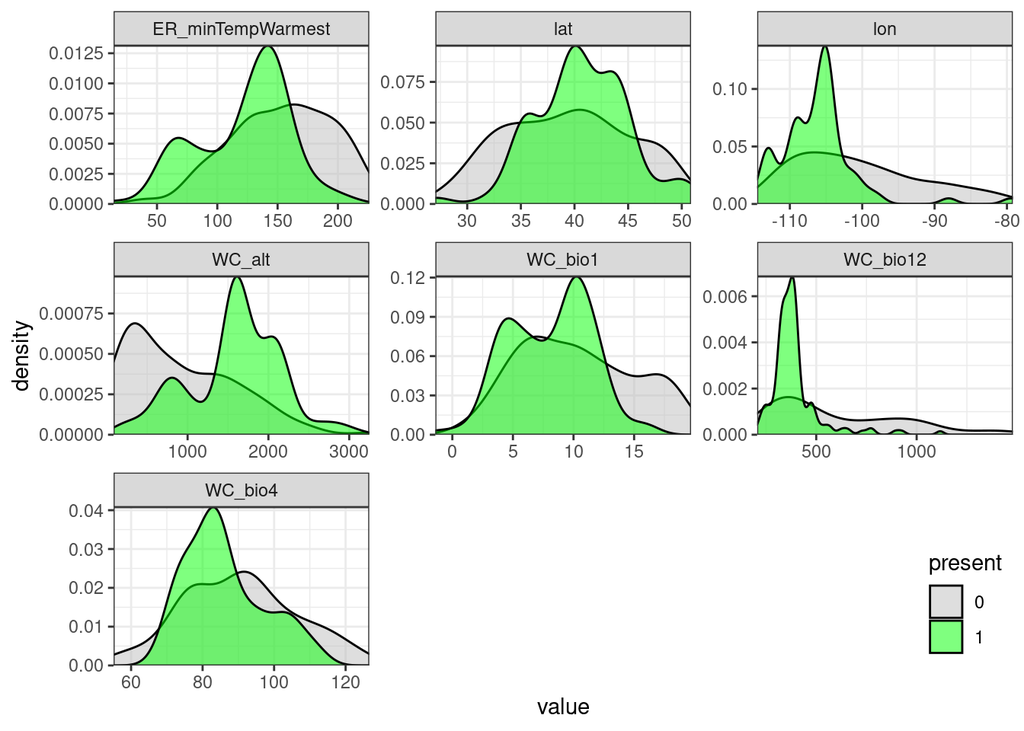

```r
pts_env %>%
  select(-ID) %>%
  mutate(
    present = factor(present)) %>%
  pivot_longer(-present) %>%
  ggplot() +
  geom_density(aes(x = value, fill = present)) +
  scale_fill_manual(values = alpha(c("gray", "green"), 0.5)) +
  scale_x_continuous(expand=c(0,0)) +
  scale_y_continuous(expand=c(0,0)) +
  theme_bw() +
  facet_wrap(~name, scales = "free") +
  theme(
    legend.position = c(1, 0),
    legend.justification = c(1, 0))
```